[figure not shown]

# Makro II: Zusätzliches Material

by Markus Mößler

# VGR: Entstehung, Verwendung und Veteilung

*Dieses Dokument enthält eine Auswertung der VGR Daten von der OECD.*

## Vorbereitung

Wir verwenden die vierteljährlichen VGR Daten von der Organisation für wirtschaftliche Zusammenarbeit und Entwicklung (OECD).

Die Daten können über das R-Paket `oecd` direkt in die Software R geladen werden.

- R-Paket `oecd`, [Link](https://cran.r-project.org/web/packages/OECD/index.html): Search and extract data from the OECD
- Heruntergelden werden R-Pakete mit: `install.packages(OECD)`.
- Geladen werden R-Pakete mit: `library(OECD)`.

Für die Auswertung verwenden wir vorwiegend *R*-Pakete der *base environment* enthalten sind.

Außerde verwenden wir außerdem folgenden R-Pakete:

- `ggplot2`, [Link](https://cran.r-project.org/web/packages/ggplot2/index.html): Create elegant data visualisations using the grammar of graphics
- `dplyr`, [Link](https://cran.r-project.org/web/packages/dplyr/index.html): A grammar of data manipulation
- `tidyr`, [Link](https://cran.r-project.org/web/packages/tidyr/index.html): Tidy messy data
- `lubridate`, [Link](https://cran.r-project.org/web/packages/lubridate/index.html): Make dealing with dates a little easier
- `scales`, [Link](https://cran.r-project.org/web/packages/scales/index.html): Scale functions for visualization
- `zoo`, [Link](https://cran.r-project.org/web/packages/zoo/index.html): S3 Infrastructure for Regular and Irregular Time Series (Z’s Ordered Observations)

Hinweis: Eine benutzerfreundlichere Implementierung würde mehr die Pakete `dplyr`, `tidyr` einbeziehen.

Die folgenden *R*-Pakete werden für die Darstellung der Ergebnisse verwendet:

- `gridExtra`, [Link](https://cran.r-project.org/web/packages/gridExtra/index.html): Miscellaneous functions for “grid” graphics
- `kableExtra`, [Link](https://cran.r-project.org/web/packages/kableExtra/index.html): Construct complex table with ‘kable’ and pipe syntax

```r
library(gridExtra)
library(kableExtra)
```

Die folgenden *R*-Funktionen werden zur Berechnung von Anteilen, Differenzen, und Wachstumsbeiträgen verwendet.

```r
L01.fun  <- function(x) (lag(x, n = 1)) # Construct lag
D01.fun  <- function(x) (lag(x, n = 0) - lag(x, n = 1)) # Construct difference
G01.fun  <- function(x) ((lag(x, n = 0) - lag(x, n = 1))/lag(x, n = 1)*100) # Construct growth rate
X00.fun  <- function(x,y) (x/y)*100 # Construct share
GX01.fun <- function(x,y) ((lag(x, n = 0) - lag(x, n = 1))/lag(x, n = 1)*100*lag(x, n = 1)/lag(y, n = 1)) # Construct growth contribution
```

Die folgenden *R*-Funktionen werden verwendet um ausgewählte Transformationen der Daten vorzunehmen.

```r
dat.man.fun.xx <- function(dat.fra, arg.lis, col.nam.sel, col.nam.out){

  # dat.fra <- dat.01
  # arg.lis <- list(X = NULL, MARGIN = 1, FUN = "sum")
  # col.nam.sel <- sub.inp.lis[[ii]]
  # col.nam.out <- sub.inp.lab[[ii]]



  # add dat.fra as first element to list
  arg.lis[[1]] <- dat.fra

  # select columns of dat.fra
  dat.fra <- arg.lis[[1]]
  arg.lis[[1]] <- subset(arg.lis[[1]], select = col.nam.sel)

  # core only
  do.call(apply, args = arg.lis)

  # altogether
  res <- cbind(dat.fra,
               setNames(
                 as.data.frame(
                   do.call(
                     apply, args = arg.lis)), col.nam.out))

  return(res)

}
```

```r
oecd.qna.fun.xx <- function(dat, loc, sub, mea, fre, sta.dat, end.dat, sub.inp.lis) {

  # # inputs
  # dat <- qna.dat.00
  # loc <- loc
  # sub <- sub
  # mea <- mea
  # fre <- fre
  # sta.dat <- sta.dat
  # end.dat <- end.dat
  # sub.inp.lis <- sub.inp.lis



  # Download if necessary!
  if(is.null(dat)){
    # Input list
    fil <- list(loc, sub, mea, fre)
    # > Download
    qna.dat <- get_dataset(dataset = "QNA", filter = fil) %>%
      subset(yq(Time) %in% seq(sta.dat, end.dat, by = "quarter")) # filter time period
  }
  if(!is.null(dat)){
    qna.dat <- dat %>%
      subset(LOCATION %in% loc) %>%
      subset(SUBJECT %in% sub) %>%
      subset(MEASURE %in% mea) %>%
      subset(FREQUENCY %in% fre) %>%
      subset(yq(Time) %in% seq(sta.dat, end.dat, by = "quarter"))
  }

  # > Transform data to wide
  dat.l.00 <- qna.dat # long format
  dat.w.00 <- dat.l.00 %>%
    subset(select = c("LOCATION", "Time", "SUBJECT", "ObsValue")) %>%
    spread(SUBJECT, ObsValue) # wide format
  # Note: tidyr (1st generation) approach

  # > Construct sector aggregates
  nn <- length(sub.inp.lis)
  sub.inp.lab <- names(sub.inp.lis)
  dat.01 <- dat.w.00
  for (ii in (1:nn)) {
    dat.01 <- dat.01 %>%
      dat.man.fun.xx(list(X = NULL, MARGIN = 1, FUN = "sum"), sub.inp.lis[[ii]], sub.inp.lab[[ii]])
  }

  # > Construct sector shares
  sub.sel <- sub.inp.lab
  sub.x  <-  paste(sub.sel, "_X00", sep = "")
  sub.g  <-  paste(sub.sel, "_G01", sep = "")
  sub.gx <-  paste(sub.sel, "_GX01", sep = "")

  dat.02 <- dat.01 %>%
    dat.man.fun.xx(list(X = NULL, MARGIN = 2, FUN = "X00.fun", y = dat.01$tot), sub.sel, sub.x) %>%
    dat.man.fun.xx(list(X = NULL, MARGIN = 2, FUN = "G01.fun"), sub.sel, sub.g) %>%
    dat.man.fun.xx(list(X = NULL, MARGIN = 2, FUN = "GX01.fun", y = dat.01$tot), sub.sel, sub.gx)

  dat.03 <- dat.02 %>%
    subset(select = c("LOCATION", "Time", sub.sel, sub.x,sub.g,sub.gx))

  # > Select values and transform wide to long
  dat.04 <- dat.02 %>%
    gather(SUBJECT,ObsValue,sub.sel[1]:sub.gx[nn]) %>% # long format
    subset(select = c("LOCATION", "Time", "SUBJECT", "ObsValue"))

  ret.lis <- list(dat = dat.02,
                  dat.03 = dat.03,
                  dat.04 = dat.04,
                  sub.sel = sub.sel, sub.x = sub.x, sub.g = sub.g, sub.gx = sub.gx,
                  end.dat = end.dat, sta.dat = sta.dat,
                  nn = nn)

  return(ret.lis)

}
```

Überblick

Beispiel: Land Deutschland, 2018

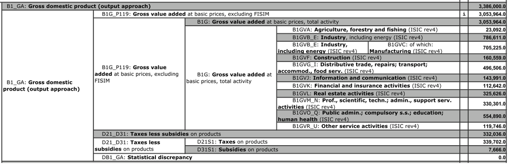

Überblick

Beispiel: Land Deutschland, 2018

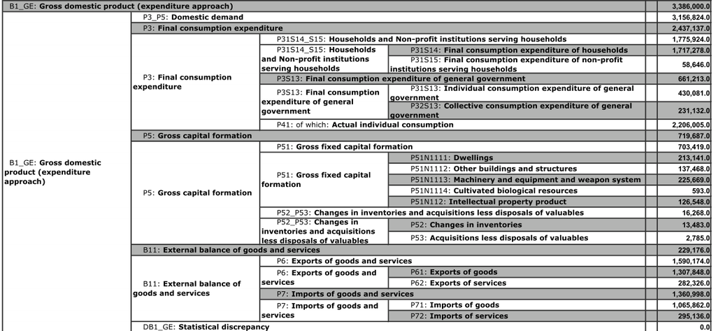

Die Struktur der VGR Daten der OECD kann duch die Funktion `get_data_structure` heruntergalden werden.

```r
# > Call get_data_structure
# qna.str <- get_data_structure("QNA")
qna.str <- OECD_get_data_structure_edit("QNA")
```

```r
qna.str$VAR_DESC
```

```
##                 id        description
## 1         LOCATION            Country
## 2          SUBJECT            Subject
## 3          MEASURE            Measure
## 4        FREQUENCY          Frequency
## 5             TIME             Period
## 6        OBS_VALUE  Observation Value
## 7      TIME_FORMAT        Time Format
## 8       OBS_STATUS Observation Status
## 9             UNIT               Unit
## 10       POWERCODE    Unit multiplier
## 11 REFERENCEPERIOD   Reference period
```

Die Daten können duch die Funktion `get_dataset` heruntergalden werden.

```r
# > Inputs for download
# loc <- qna.str$LOCATION[,1]
loc <- c("DEU", "FRA", "ITA", "EA19", "GBR", "USA")
sub <- qna.str$SUBJECT[,1]
mea <- c("LNBQRSA") # Measure: Constant prices seasonal adjusted
fre <- c("Q") # Frequency: Quarterly frequency
sta.dat <- as.Date("2005-01-01") # Periods: "yyyy-mm-dd"
end.dat <- as.Date("2022-10-01")
# Note: Q1: 2020-01-01; Q2: 2020-04-01; Q3: 2020-07-01; Q4: 2020-10-01
fil <- list(loc, sub, mea, fre) # Collect inputs for get_dataset function

# > Download
# qna.dat.00 <- get_dataset(dataset = "QNA", filter = fil) %>%
#   mutate(Time = Time) %>%
#   subset(yq(Time) %in% seq(sta.dat, end.dat, by = "quarter")) # filter time period

# > Download
qna.dat.00 <- get_dataset(dataset = "QNA", filter = fil)

# qna.dat.00 <- get_dataset(dataset = "QNA", filter = fil) %>%
#   subset(yq(Time) %in% seq(sta.dat, end.dat, by = "quarter")) # filter time period

qna.dat.00 <- get_dataset(dataset = "QNA", filter = fil) %>%
  subset(yq(Time) %in% seq(sta.dat, end.dat, by = "quarter")) # filter time period

qna.dat.00$ObsValue <- as.numeric(qna.dat.00$ObsValue)

head(qna.dat.00)
```

```
## # A tibble: 6 × 11
##   FREQUENCY LOCATION MEASURE OBS_STATUS ObsValue POWERCODE REFERENCEPERIOD SUBJECT TIME_FORMAT Time    UNIT
##   <chr>     <chr>    <chr>   <chr>         <dbl> <chr>     <chr>           <chr>   <chr>       <chr>   <chr>
## 1 Q         FRA      LNBQRSA <NA>        492039. 6         2014            B1_GA   P3M         2005-Q1 EUR
## 2 Q         FRA      LNBQRSA <NA>        493409. 6         2014            B1_GA   P3M         2005-Q2 EUR
## 3 Q         FRA      LNBQRSA <NA>        496138. 6         2014            B1_GA   P3M         2005-Q3 EUR
## 4 Q         FRA      LNBQRSA <NA>        499449  6         2014            B1_GA   P3M         2005-Q4 EUR
## 5 Q         FRA      LNBQRSA <NA>        503272. 6         2014            B1_GA   P3M         2006-Q1 EUR
## 6 Q         FRA      LNBQRSA <NA>        508509. 6         2014            B1_GA   P3M         2006-Q2 EUR
```

Zurück zur *Startseite*

## Entstehung

### Deutschland

```r
# > Germany, output
loc <- c("DEU") # Location: Germany
mea <- c("LNBQRSA") # Measure: Constant prices seasonal adjusted
fre <- c("Q") # Frequency: Quarterly frequency
sta.dat <- as.Date("2005-01-01") # Periods: "yyyy-mm-dd"
end.dat <- as.Date("2022-10-01")
# Note: Q1: 2020-01-01; Q2: 2020-04-01; Q3: 2020-07-01; Q4: 2020-10-01

sub <- c("B1_GA","B1GVA","B1GVB_E","B1GVF","B1GVG_I","B1GVJ","B1GVK","B1GVL","B1GVM_N","B1GVO_Q","B1GVR_U","D21_D31")
sub.agr <- c("B1GVA")
sub.ind <- c("B1GVB_E")
sub.con <- c("B1GVF")
sub.ser <- c("B1GVG_I","B1GVJ","B1GVK","B1GVL","B1GVM_N","B1GVO_Q","B1GVR_U")
sub.tls <- c("D21_D31") # taxes less subsidies on products
sub.tot <- c("B1_GA")
sub.inp.lis <- list(agr = sub.agr,
                    ind = sub.ind,
                    con = sub.con,
                    ser = sub.ser,
                    tls = sub.tls,
                    tot = sub.tot)

ger.out.01.res <- oecd.qna.fun.xx(qna.dat.00, loc, sub, mea, fre, sta.dat, end.dat, sub.inp.lis)
```

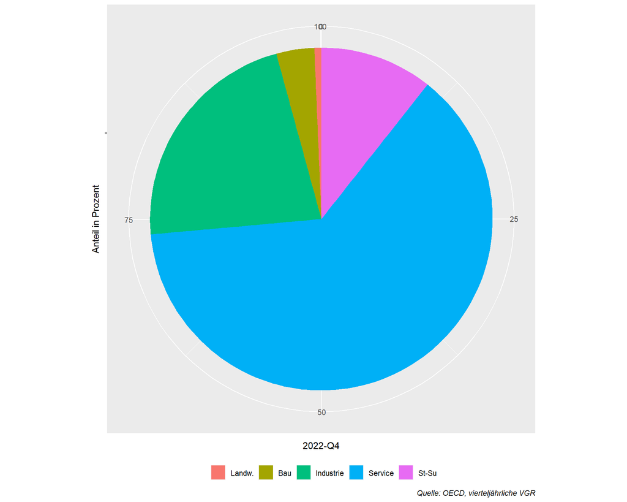

```r
# > Inputs
oecd.qna.res <- ger.out.01.res

dat.inp <- oecd.qna.res$dat.04 %>%
  subset(yq(Time) %in% oecd.qna.res$end.dat) %>%
  subset(SUBJECT %in% oecd.qna.res$sub.x[-oecd.qna.res$nn])

# > Labels
lab.inp <- c("Landw.",
             "Bau",
             "Industrie",
             "Service",
             "St-Su")

# > Plot shares as pieplot
plt.x <- dat.inp %>%
  ggplot(aes(x = "", y = ObsValue, fill = SUBJECT)) +
  geom_bar(width = 1, stat = "identity") +
  coord_polar("y") +
  scale_fill_discrete(name = "", labels = lab.inp) +
  theme(legend.position = "bottom") +
  labs(x = "Anteil in Prozent", y = dat.inp[1,"Time"],
       caption = "Quelle: OECD, vierteljährliche VGR") +
  theme(plot.caption = element_text(face = "italic"))
plt.x
```

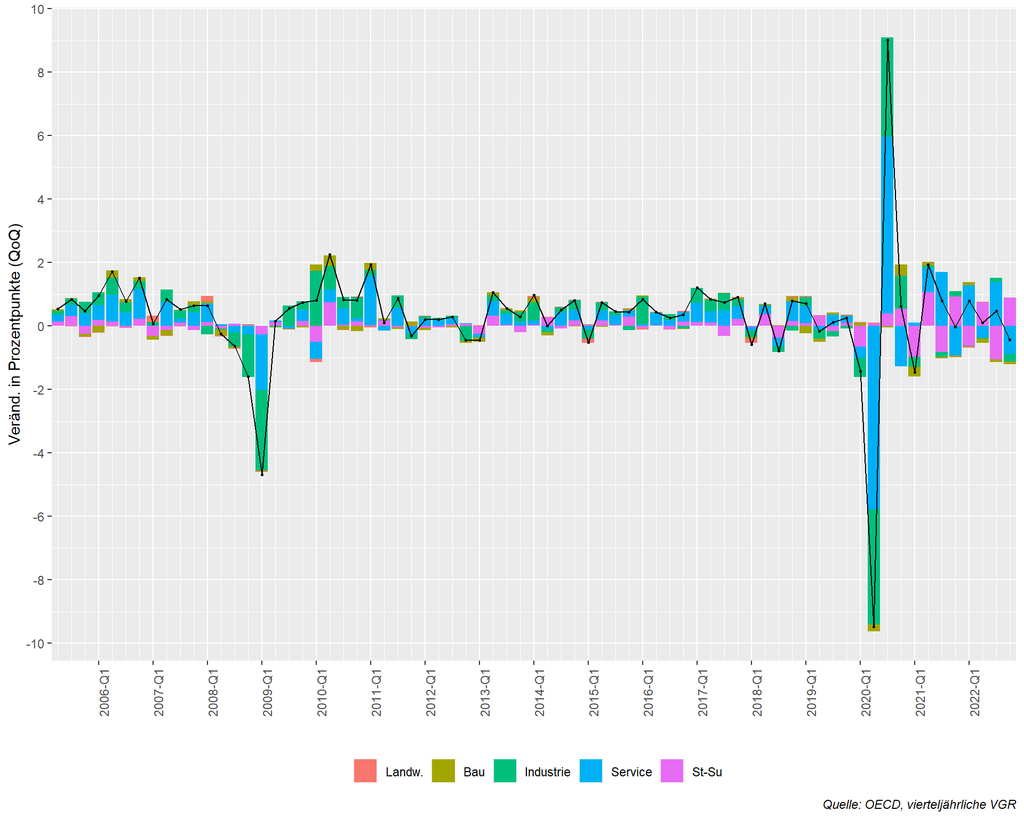

```r
# > Inputs
oecd.qna.res <- ger.out.01.res

dat.inp <- oecd.qna.res$dat.04 %>%
  subset(yq(Time) %in% seq(as.Date(oecd.qna.res$sta.dat),as.Date(oecd.qna.res$end.dat),0.25)[-1]) %>%
  subset(SUBJECT %in% oecd.qna.res$sub.gx)

# > Labels
lab.inp <- c("Landw.",
             "Bau",
             "Industrie",
             "Service",
             "St-Su")

# > Plot growth contributions
plt.gx <- dat.inp %>%
  ggplot() +
  geom_bar(aes(y = ObsValue, x = as.yearqtr(Time, "%Y-Q%q"), fill = SUBJECT), position = "stack", stat = "identity", subset(dat.inp,SUBJECT %in% oecd.qna.res$sub.gx[-oecd.qna.res$nn])) +
  geom_point(aes(y = ObsValue, x = as.yearqtr(Time, "%Y-Q%q")), subset(dat.inp,SUBJECT %in% oecd.qna.res$sub.gx[oecd.qna.res$nn]), size = 0.5) +
  geom_line(aes(y = ObsValue, x = as.yearqtr(Time, "%Y-Q%q")), subset(dat.inp,SUBJECT %in% oecd.qna.res$sub.gx[oecd.qna.res$nn]), size = 0.5) +
  scale_fill_discrete(name="",labels = lab.inp) +
  theme(legend.position = "bottom") +
  labs(x = "",y = "Veränd. in Prozentpunkte (QoQ)",
       caption = "Quelle: OECD, vierteljährliche VGR") +
  theme(axis.text.x = element_text(angle = 90),
        plot.caption = element_text(face = "italic")) +
  scale_x_yearqtr(breaks = seq(as.yearqtr(oecd.qna.res$sta.dat), as.yearqtr(oecd.qna.res$end.dat), 1)[-1],
                  minor_breaks = seq(as.yearqtr(oecd.qna.res$sta.dat), as.yearqtr(oecd.qna.res$end.dat), 0.25)[-1],
                  format = "%Y-Q%q",
                  expand = c(0, 0)) +
  scale_y_continuous(breaks = seq(-10, 10, 2))
plt.gx
```

Zurück zur *Startseite*

### Vergleich

```r
oecd.qna.out <- function(loc, sta.dat, end.dat){


  # > Data preparation
  # loc <- c("DEU") # Location: Germany
  mea <- c("LNBQRSA") # Measure: Constant prices seasonal adjusted
  fre <- c("Q") # Frequency: Quarterly frequency
  # sta.dat <- as.Date("2005-01-01") # Periods: "yyyy-mm-dd"
  # end.dat <- as.Date("2022-10-01")
  # Note: Q1: 2020-01-01; Q2: 2020-04-01; Q3: 2020-07-01; Q4: 2020-10-01

  sub <- c("B1_GA","B1GVA","B1GVB_E","B1GVF","B1GVG_I","B1GVJ","B1GVK","B1GVL","B1GVM_N","B1GVO_Q","B1GVR_U","D21_D31")
  sub.agr <- c("B1GVA")
  sub.ind <- c("B1GVB_E")
  sub.con <- c("B1GVF")
  sub.ser <- c("B1GVG_I","B1GVJ","B1GVK","B1GVL","B1GVM_N","B1GVO_Q","B1GVR_U")
  sub.tls <- c("D21_D31") # taxes less subsidies on products
  sub.tot <- c("B1_GA")
  sub.inp.lis <- list(agr = sub.agr,
                      ind = sub.ind,
                      con = sub.con,
                      ser = sub.ser,
                      tls = sub.tls,
                      tot = sub.tot)

  out.01.res <- oecd.qna.fun.xx(qna.dat.00, loc, sub, mea, fre, sta.dat, end.dat, sub.inp.lis)


  # > Illustration share levels
  oecd.qna.res <- out.01.res

  dat.inp <- oecd.qna.res$dat.04 %>%
    subset(yq(Time) %in% oecd.qna.res$end.dat) %>%
    subset(SUBJECT %in% oecd.qna.res$sub.x[-oecd.qna.res$nn])

  # >> Labels
  lab.inp <- c("Landw.",
               "Bau",
               "Industrie",
               "Service",
               "St-Su")

  # >> Plot shares as pieplot
  plt.x <- dat.inp %>%
    ggplot(aes(x = "", y = ObsValue, fill = SUBJECT)) +
    geom_bar(width = 1, stat = "identity") +
    coord_polar("y") +
    scale_fill_discrete(name = "", labels = lab.inp) +
    theme(legend.position = "bottom") +
    labs(x = "Anteil in Prozent", y = dat.inp[1,"Time"],
         caption = "Quelle: OECD, vierteljährliche VGR") +
    theme(plot.caption = element_text(face = "italic"))


  # > Illustration growth contribution
  oecd.qna.res <- out.01.res

  dat.inp <- oecd.qna.res$dat.04 %>%
    subset(yq(Time) %in% seq(as.Date(oecd.qna.res$sta.dat), as.Date(oecd.qna.res$end.dat), 0.25)[-1]) %>%
    subset(SUBJECT %in% oecd.qna.res$sub.gx)

  # >> Labels
  lab.inp <- c("Landw.",
               "Bau",
               "Industrie",
               "Service",
               "St-Su")

  # >> Plot growth contributions
  plt.gx <- dat.inp %>%
    ggplot() +
    geom_bar(aes(y = ObsValue, x = as.yearqtr(Time, "%Y-Q%q"), fill = SUBJECT), position = "stack", stat = "identity", subset(dat.inp,SUBJECT %in% oecd.qna.res$sub.gx[-oecd.qna.res$nn])) +
    geom_point(aes(y = ObsValue, x = as.yearqtr(Time, "%Y-Q%q")), subset(dat.inp,SUBJECT %in% oecd.qna.res$sub.gx[oecd.qna.res$nn]), size = 0.5) +
    geom_line(aes(y = ObsValue, x = as.yearqtr(Time, "%Y-Q%q")), subset(dat.inp,SUBJECT %in% oecd.qna.res$sub.gx[oecd.qna.res$nn]), size = 0.5) +
    scale_fill_discrete(name = "", labels = lab.inp) +
    theme(legend.position = "bottom") +
    labs(x = "", y = "Veränd. in Prozentpunkte (QoQ)",
         caption = "Quelle: OECD, vierteljährliche VGR") +
    theme(axis.text.x = element_text(angle = 90),
          plot.caption = element_text(face = "italic")) +
    scale_x_yearqtr(breaks = seq(as.yearqtr(oecd.qna.res$sta.dat), as.yearqtr(oecd.qna.res$end.dat), 1)[-1],
                    minor_breaks = seq(as.yearqtr(oecd.qna.res$sta.dat), as.yearqtr(oecd.qna.res$end.dat), 0.25)[-1],
                    format = "%Y-Q%q",
                    expand = c(0, 0)) +
    scale_y_continuous(breaks = seq(-20, 20, 2))

  ret.lis <- list(plt.x=plt.x, plt.gx=plt.gx, out.01.res=out.01.res, lab.inp=lab.inp)

  return(ret.lis)

}
```

```r
# > Start and end date
sta.dat <- as.Date("2005-01-01") # Periods: "yyyy-mm-dd"
end.dat <- as.Date("2022-10-01")
# Note: Q1: 2020-01-01; Q2: 2020-04-01; Q3: 2020-07-01; Q4: 2020-10-01

# > Germany
loc <- c("DEU")
oecd.qna.out.ger <- oecd.qna.out(loc, sta.dat, end.dat)
# > France
loc <- c("FRA")
oecd.qna.out.fra <- oecd.qna.out(loc, sta.dat, end.dat)
# > Italy
loc <- c("ITA")
oecd.qna.out.ita <- oecd.qna.out(loc, sta.dat, end.dat)
# # > USA
# loc <- c("USA")
# oecd.qna.out.usa <- oecd.qna.out(loc, sta.dat, end.dat)
# > Eurozone
loc <- c("EA19")
oecd.qna.out.ea19 <- oecd.qna.out(loc, sta.dat, end.dat)
# > United Kingdom
loc <- c("GBR")
oecd.qna.out.gbr <- oecd.qna.out(loc, sta.dat, end.dat)
```

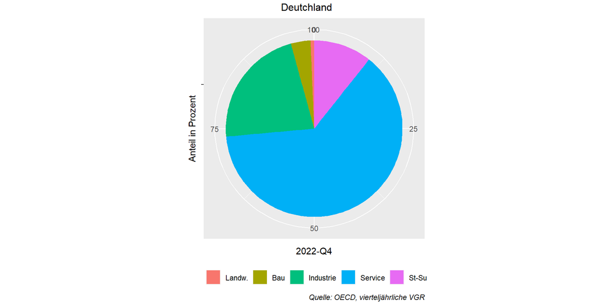

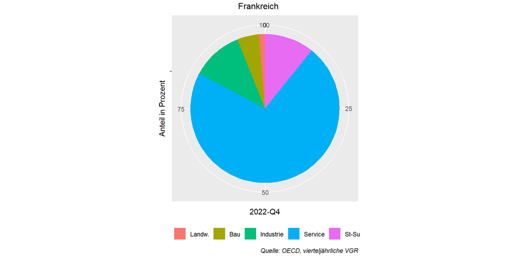

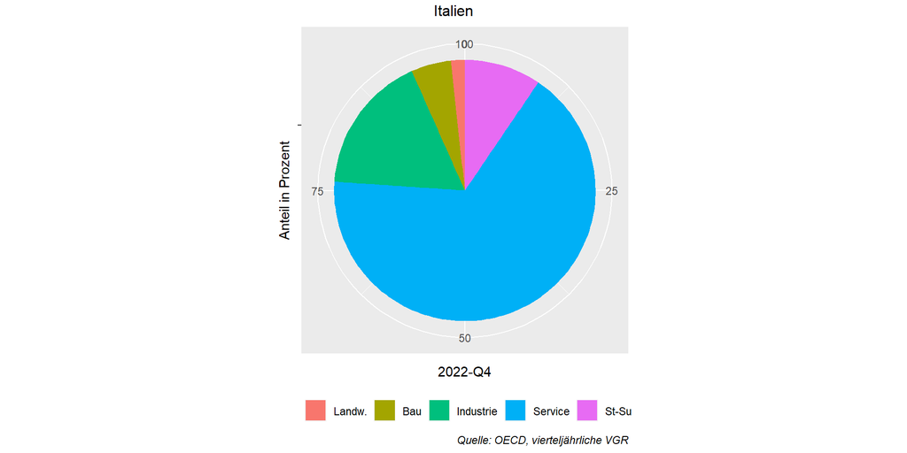

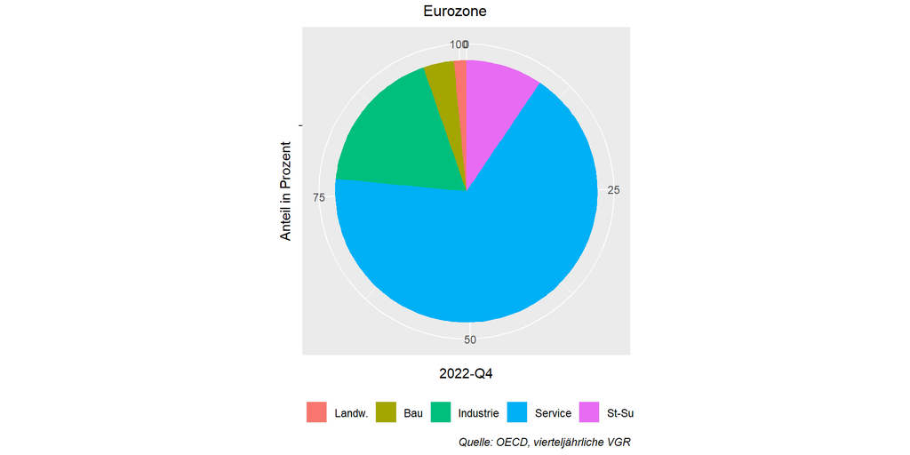

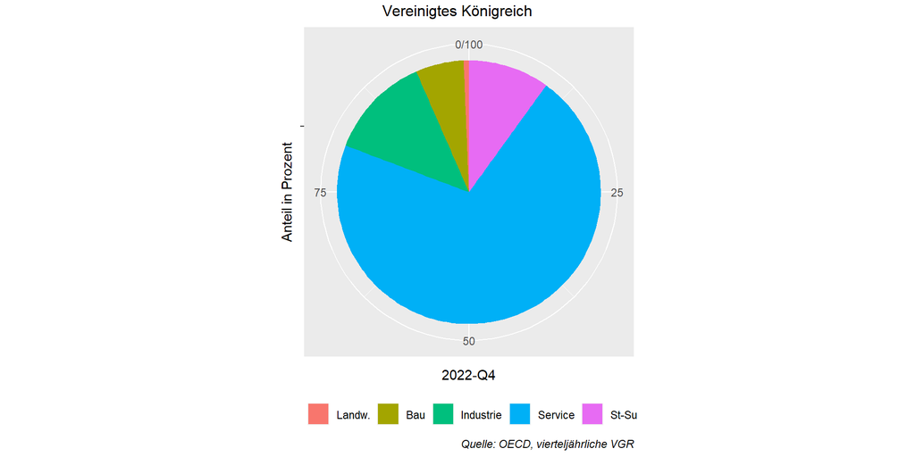

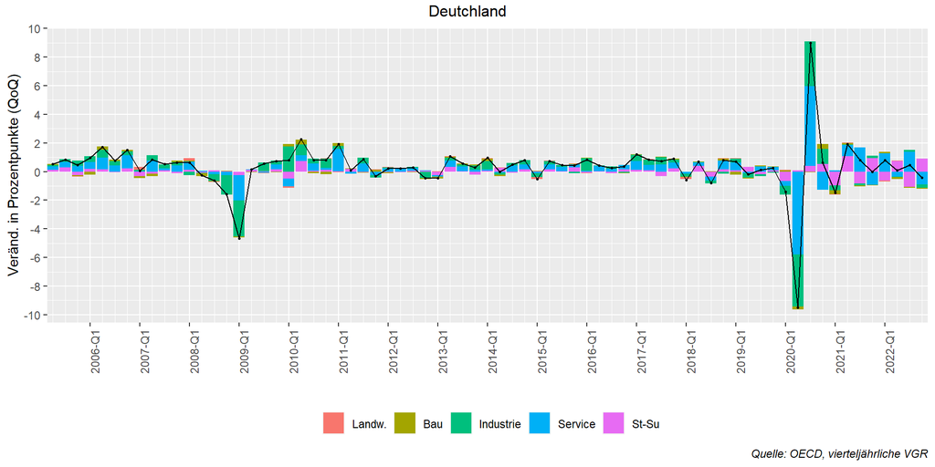

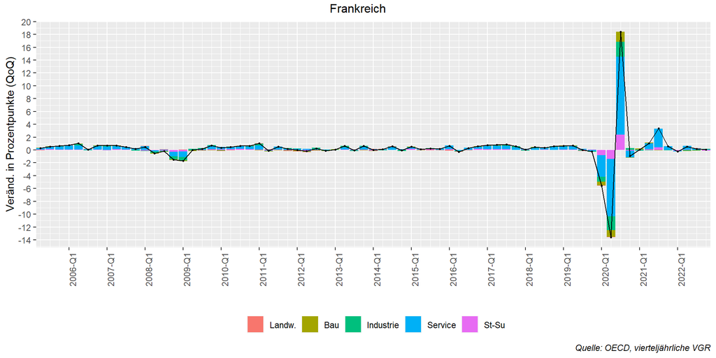

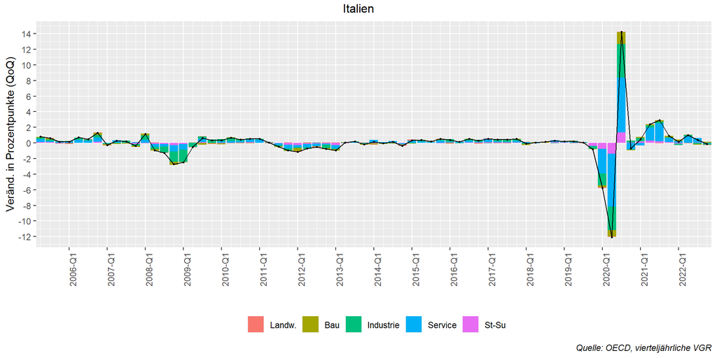

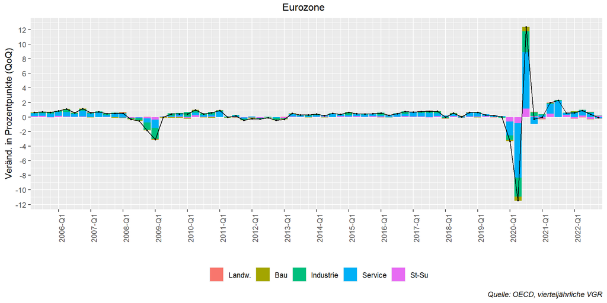

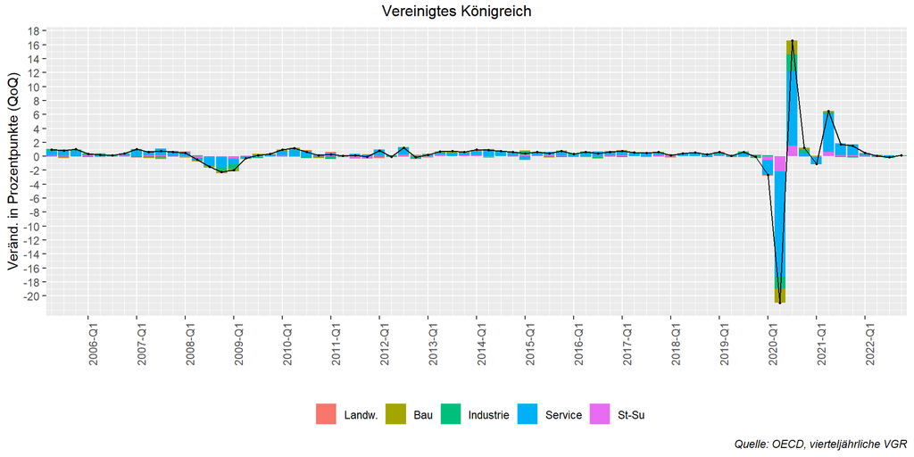

Zurück zur *Startseite*

## Verwendung

### Deutschland

```r
# > Germany, expenditure
loc <- c("DEU") # Location: Germany
mea <- c("LNBQRSA") # Measure: Constant prices seasonal adjusted
fre <- c("Q") # Frequency: Quarterly frequency
sta.dat <- as.Date("2005-01-01") # Periods: "yyyy-mm-dd"
end.dat <- as.Date("2022-10-01")
# Note: Q1: 2020-01-01; Q2: 2020-04-01; Q3: 2020-07-01; Q4: 2020-10-01

sub <- c("B1_GE","P3","P5","B11")
sub.con <- c("P3")
sub.inv <- c("P5")
sub.ext <- c("B11")
sub.tot <- c("B1_GE")
sub.inp.lis <- list(con = sub.con,
                    inv = sub.inv,
                    ext = sub.ext,
                    tot = sub.tot)

ger.exp.01.res <- oecd.qna.fun.xx(qna.dat.00, loc,sub, mea, fre, sta.dat, end.dat, sub.inp.lis)
```

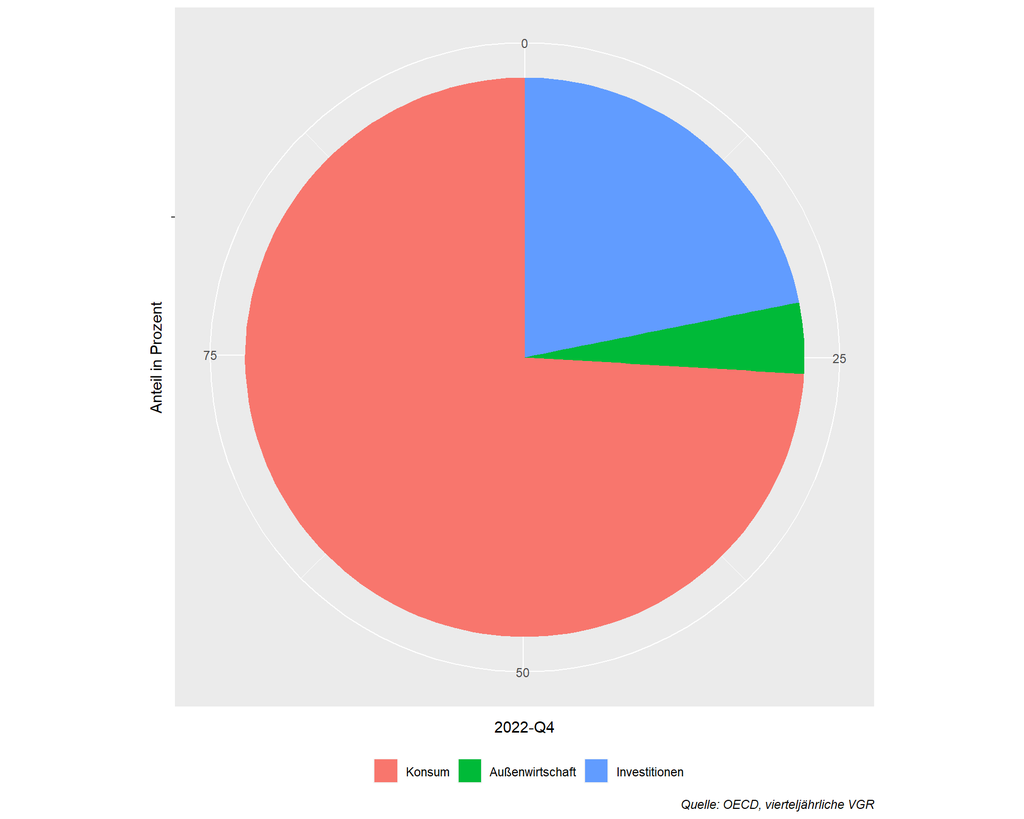

```r
# > Inputs
oecd.qna.res <- ger.exp.01.res

dat.inp <- oecd.qna.res$dat.04 %>%
  subset(yq(Time) %in% oecd.qna.res$end.dat) %>%
  subset(SUBJECT %in% oecd.qna.res$sub.x[-oecd.qna.res$nn])

# > Labels
lab.inp <- c("Konsum",
             "Außenwirtschaft",
             "Investitionen")

# > Plot shares as pieplot
plt.x <- dat.inp %>%
  ggplot(aes(x = "", y = ObsValue, fill = SUBJECT)) +
  geom_bar(width = 1, stat = "identity") +
  coord_polar("y") +
  scale_fill_discrete(name = "", labels = lab.inp) +
  theme(legend.position = "bottom") +
  labs(x = "Anteil in Prozent", y = dat.inp[1,"Time"],
       caption = "Quelle: OECD, vierteljährliche VGR") +
  theme(plot.caption = element_text(face = "italic"))
plt.x
```

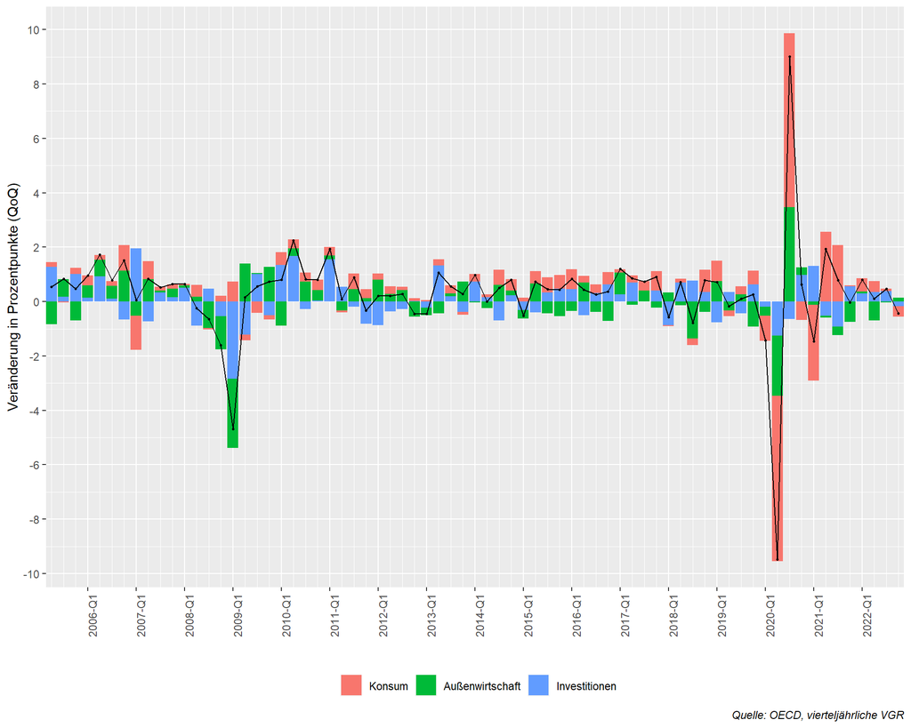

```r
# > Inputs
oecd.qna.res <- ger.exp.01.res

dat.inp <- oecd.qna.res$dat.04 %>%
  subset(yq(Time) %in% seq(as.Date(oecd.qna.res$sta.dat), as.Date(oecd.qna.res$end.dat), 0.25)[-1]) %>%
  subset(SUBJECT %in% oecd.qna.res$sub.gx)

# > Labels
lab.inp <- c("Konsum",
             "Außenwirtschaft",
             "Investitionen")

# > Plot growth contributions
plt.gx <- dat.inp %>%
  ggplot() +
  geom_bar(aes(y = ObsValue, x = as.yearqtr(Time, "%Y-Q%q"), fill = SUBJECT), position = "stack", stat = "identity", subset(dat.inp, SUBJECT %in% oecd.qna.res$sub.gx[-oecd.qna.res$nn])) +
  geom_point(aes(y = ObsValue, x = as.yearqtr(Time, "%Y-Q%q")), subset(dat.inp, SUBJECT %in% oecd.qna.res$sub.gx[oecd.qna.res$nn]), size = 0.5) +
  geom_line(aes(y = ObsValue, x = as.yearqtr(Time, "%Y-Q%q")), subset(dat.inp,SUBJECT %in% oecd.qna.res$sub.gx[oecd.qna.res$nn]), size = 0.5) +
  scale_fill_discrete(name = "", labels = lab.inp) +
  theme(legend.position = "bottom") +
  labs(x = "", y = "Veränderung in Prozentpunkte (QoQ)",
       caption = "Quelle: OECD, vierteljährliche VGR") +
  theme(axis.text.x = element_text(angle = 90),
        plot.caption = element_text(face = "italic")) +
  scale_x_yearqtr(breaks = seq(as.yearqtr(oecd.qna.res$sta.dat), as.yearqtr(oecd.qna.res$end.dat), 1)[-1],
                  minor_breaks = seq(as.yearqtr(oecd.qna.res$sta.dat), as.yearqtr(oecd.qna.res$end.dat), 0.25)[-1],
                  format = "%Y-Q%q",
                  expand = c(0, 0)) +
  scale_y_continuous(breaks = seq(-10, 10, 2))

plt.gx
```

Zurück zur *Startseite*

### Vergleich

```r
oecd.qna.exp <- function(loc,sta.dat,end.dat){


  # > Data preparation
  # loc <- c("DEU") # Location: Germany
  mea <- c("LNBQRSA") # Measure: Constant prices seasonal adjusted
  fre <- c("Q") # Frequency: Quarterly frequency
  # sta.dat <- as.Date("2005-01-01") # Periods: "yyyy-mm-dd"
  # end.dat <- as.Date("2022-10-01")
  # Note: Q1: 2020-01-01; Q2: 2020-04-01; Q3: 2020-07-01; Q4: 2020-10-01

  sub <- c("B1_GE","P3","P5","B11")
  sub.con <- c("P3")
  sub.inv <- c("P5")
  sub.ext <- c("B11")
  sub.tot <- c("B1_GE")
  sub.inp.lis <- list(con = sub.con,
                      inv = sub.inv,
                      ext = sub.ext,
                      tot = sub.tot)

  exp.01.res <- oecd.qna.fun.xx(qna.dat.00, loc, sub, mea, fre, sta.dat, end.dat, sub.inp.lis)


  # > Illustration share levels
  oecd.qna.res <- exp.01.res

  dat.inp <- oecd.qna.res$dat.04 %>%
    subset(yq(Time) %in% oecd.qna.res$end.dat) %>%
    subset(SUBJECT %in% oecd.qna.res$sub.x[-oecd.qna.res$nn])

  # > Labels
  lab.inp <- c("Konsum",
               "Außenwirtschaft",
               "Investitionen")

  # > Plot shares as pieplot
  plt.x <- dat.inp %>%
    ggplot(aes(x = "", y = ObsValue, fill = SUBJECT)) +
    geom_bar(width = 1, stat = "identity") +
    coord_polar("y") +
    scale_fill_discrete(name = "", labels = lab.inp) +
    theme(legend.position = "bottom") +
    labs(x = "Anteil in Prozent", y = dat.inp[1,"Time"],
         caption = "Quelle: OECD, vierteljährliche VGR") +
    theme(plot.caption = element_text(face = "italic"))


  # > Illustration growth contribution
  oecd.qna.res <- exp.01.res

  dat.inp <- oecd.qna.res$dat.04 %>%
    subset(yq(Time) %in% seq(as.Date(oecd.qna.res$sta.dat), as.Date(oecd.qna.res$end.dat), 0.25)[-1]) %>%
    subset(SUBJECT %in% oecd.qna.res$sub.gx)

  # > Labels
  lab.inp <- c("Konsum",
               "Außenwirtschaft",
               "Investitionen")

  # > Plot growth contributions
  plt.gx <- dat.inp %>%
    ggplot() +
    geom_bar(aes(y = ObsValue, x = as.yearqtr(Time, "%Y-Q%q"), fill = SUBJECT), position = "stack", stat = "identity", subset(dat.inp,SUBJECT %in% oecd.qna.res$sub.gx[-oecd.qna.res$nn])) +
    geom_point(aes(y = ObsValue, x = as.yearqtr(Time, "%Y-Q%q")), subset(dat.inp,SUBJECT %in% oecd.qna.res$sub.gx[oecd.qna.res$nn]), size = 0.5) +
    geom_line(aes(y = ObsValue, x = as.yearqtr(Time, "%Y-Q%q")), subset(dat.inp,SUBJECT %in% oecd.qna.res$sub.gx[oecd.qna.res$nn]), size = 0.5) +
    scale_fill_discrete(name = "", labels = lab.inp) +
    theme(legend.position = "bottom") +
    labs(x = "", y = "Veränd. in Prozentpunkte (QoQ)",
         caption = "Quelle: OECD, vierteljährliche VGR") +
    theme(axis.text.x = element_text(angle = 90),
          plot.caption = element_text(face = "italic")) +
    scale_x_yearqtr(breaks = seq(as.yearqtr(oecd.qna.res$sta.dat), as.yearqtr(oecd.qna.res$end.dat), 1)[-1],
                    minor_breaks = seq(as.yearqtr(oecd.qna.res$sta.dat), as.yearqtr(oecd.qna.res$end.dat),0.25)[-1],
                    format = "%Y-Q%q",
                    expand = c(0, 0)) +
    scale_y_continuous(breaks = seq(-20, 20, 2))

  ret.lis <- list(plt.x = plt.x, plt.gx = plt.gx, exp.01.res = exp.01.res, lab.inp = lab.inp)

  return(ret.lis)

}
```

```r
# > Start and end date
sta.dat <- as.Date("2005-01-01") # Periods: "yyyy-mm-dd"
end.dat <- as.Date("2022-10-01")
# Note: Q1: 2020-01-01; Q2: 2020-04-01; Q3: 2020-07-01; Q4: 2020-10-01

# > Germany
loc <- c("DEU")
oecd.qna.exp.ger <- oecd.qna.exp(loc, sta.dat, end.dat)
# > France
loc <- c("FRA")
oecd.qna.exp.fra <- oecd.qna.exp(loc, sta.dat, end.dat)
# > Italy
loc <- c("ITA")
oecd.qna.exp.ita <- oecd.qna.exp(loc, sta.dat, end.dat)
# > USA
loc <- c("USA")
oecd.qna.exp.usa <- oecd.qna.exp(loc, sta.dat, end.dat)
# > Eurozone
loc <- c("EA19")
oecd.qna.exp.ea19 <- oecd.qna.exp(loc, sta.dat, end.dat)
# > United Kingdom
loc <- c("GBR")
oecd.qna.exp.gbr <- oecd.qna.exp(loc, sta.dat, end.dat)
```

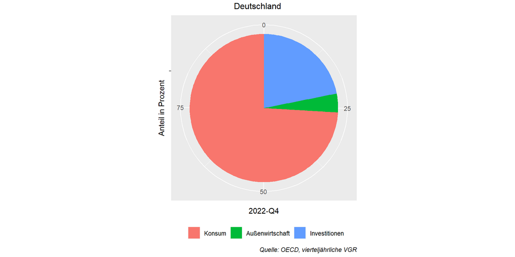

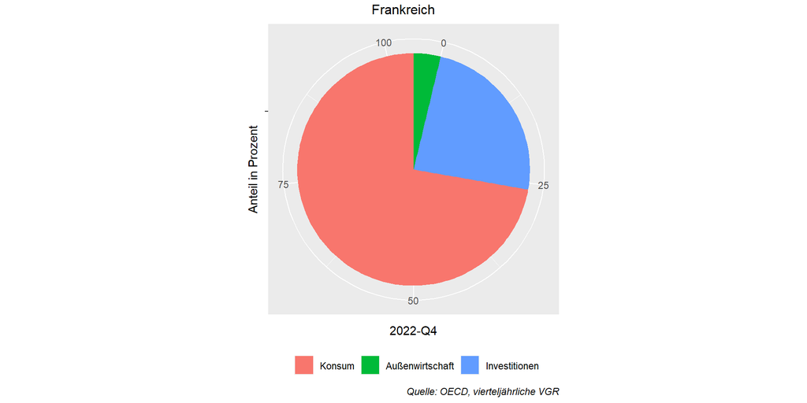

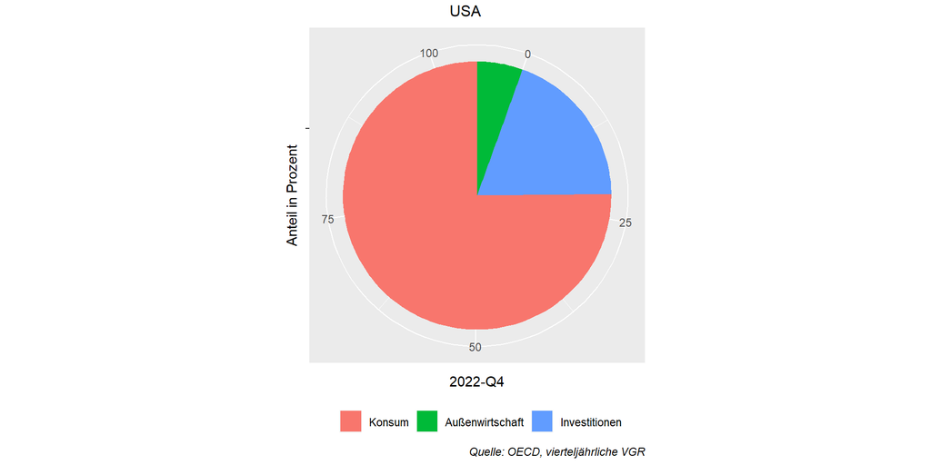

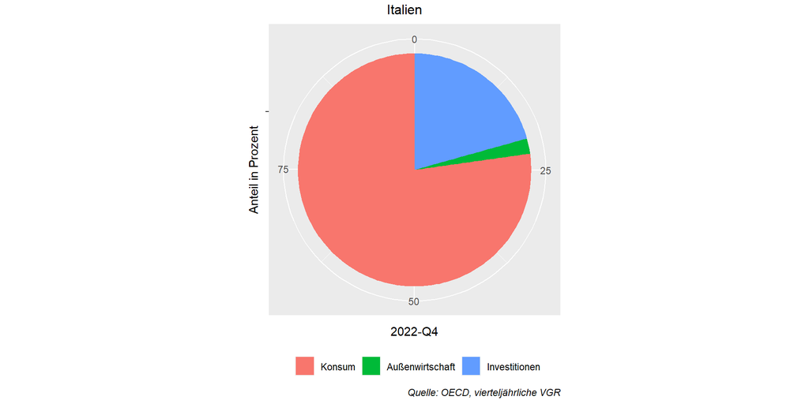

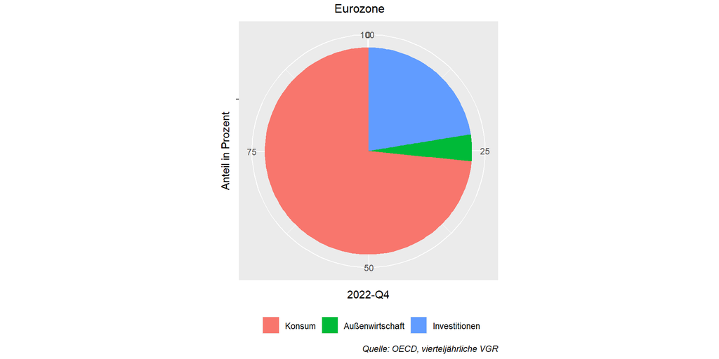

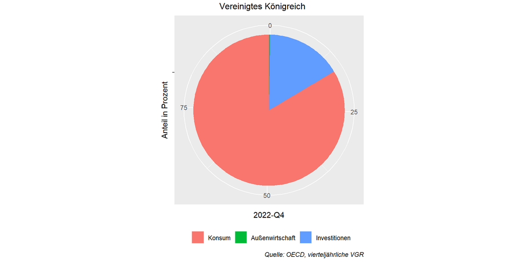

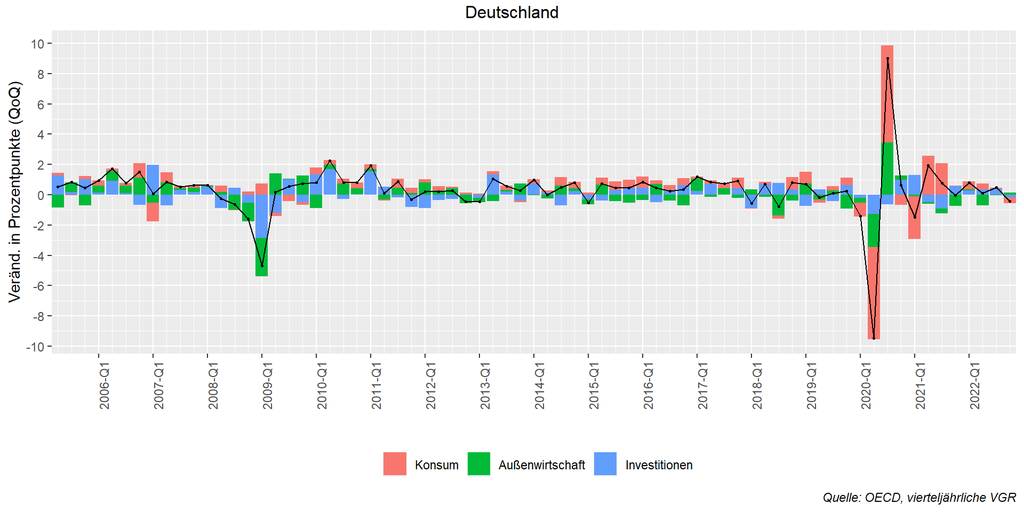

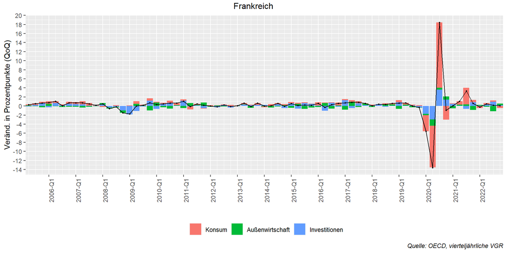

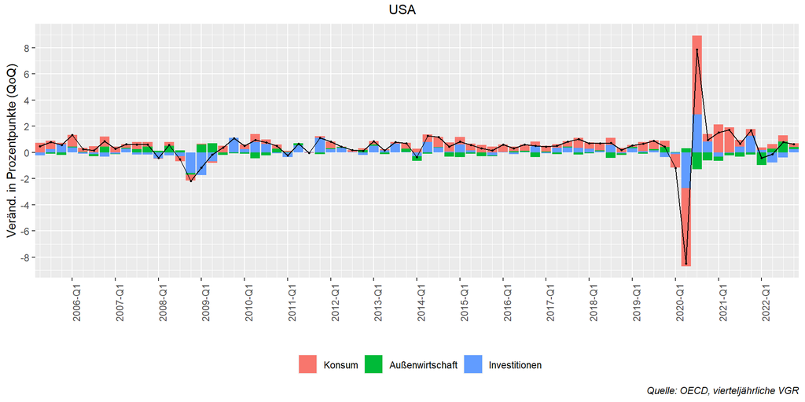

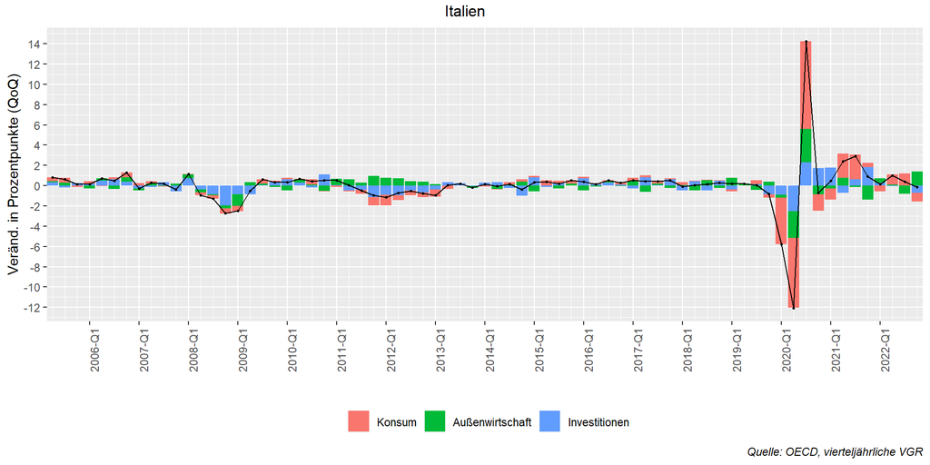

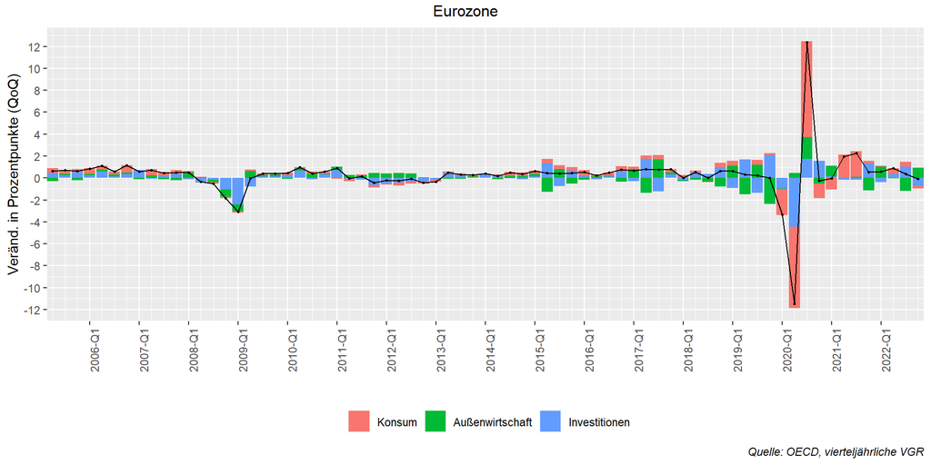

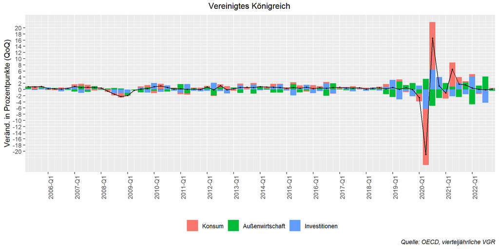

Zurück zur *Startseite*